# Gathering, Wrangling and Exploring Tweeter's Data

- Gathering The Data
- Data Wrangling
  - Assessing
  - Cleaning
- Exploratory Data Analysis

## Introduction

The data used in this project consists of three data-frames that must be transformed into one dataframe.

Two datasets were provided by Udacity, and the third will be created by gathering data using the tweeter api (*tweetpy*).

Before combining the datasets, it will be necessary to clean the data, since there are a lot of issues on it.

I have already assessed the datasets to check the data quality and tidiness issues, and I have created a list of all the issues that will be addressed in data cleaning section. After that, I'll combine the datasets and I'll start exploring interesting relationships that exists in this data.

#### Loading packages

```python
# General
import pandas as pd
import numpy as np

# Gathering
import os
import json
import tweepy # tweeter api
import requests # Downloading files programatically
from time import sleep # creating a interval between the requests for twitter

# Data Cleaning
pd.set_option('max_colwidth',150)
import re


# Tweeter Analysis project
%matplotlib inline
import matplotlib.pyplot as plt
from PIL import Image
from wordcloud import WordCloud, STOPWORDS, ImageColorGenerator
from scipy.stats import pearsonr
import seaborn as sns
plt.style.use('ggplot')
```

## Gathering the data

```python
# Manually
tweets_raw = pd.read_csv('twitter_archive_enhanced.csv')


# Downloading the image_predictions file programmatically
url = 'https://d17h27t6h515a5.cloudfront.net/topher/2017/August/599fd2ad_image-predictions/image-predictions.tsv'
image = requests.get(url)
open('image_predictions.tsv', 'wb').write(image.content)

image_predictions_raw = pd.read_csv('image_predictions.tsv', '\t')
```

#### Twitter API

```python
# Autentication
consumer_key = 'Enter here your consumer key'
consumer_secret = 'Enter your consumer secret here'
access_token = 'Enter here your access token'
access_secret = 'Enter here your access secret'

auth = tweepy.OAuthHandler(consumer_key, consumer_secret)
auth.set_access_token(access_token, access_secret)

# Creating the API
# Here I have set thte wait on rate limit to make the BOT wait, when the
# Limit of tweeter requests per hour is surpassed.
api = tweepy.API(auth, wait_on_rate_limit=True)
# Creating the file to store the json data
f = open('tweets_json.txt', 'w')
# The variable below will be increased by one, every time a new tweet is
# appended to the file
line_ = 0
data = []
json_tweet = []
# Instead of creating the file and importing it later to the notebook
# I have preferred to create a list of dictionaries to store the desired data.
for line in tweets_raw['tweet_id']:
    # Some of the api requests, were returning an empty list
    # So I have created an conditional statement, to skip those tweet_ids
    if api.statuses_lookup([line]) == []:
       print("This tweet haven't returned anything")
       continue
    else:
        tweet = api.statuses_lookup([line]) # This function return an status object
        tweet = tweet[0]
## Creating a list of dictionaries to append the data
        json.dump(tweet._json, f)
        line_ += 1
        print('Line number ' + str(line_) + ' appended to the file')
        sleep(0.1)
        f.write('\n')
f.close()
```

```python
data_raw = pd.read_json('tweets_json.txt', lines=True)
```

## Data Wrangling

### Assessing

- There are some names that are not names like: "a" (55 times), 'an' (7 times), etc.

### Issues in the dataframe

I have already lookout for the problems in the three datasets. Here are the problems that I have found:

#### Quality Issues

##### Tweets

1. There are missing data related to the retweets and replies. Those columns are ids, but they're useful to find which rows are retweets. After removing the rows that are retweets, I'll also remove those columns.
2. Wrong dtypes in the columns `timestamp` (object), `tweet_id` (int64).
3. In the column `name`, there are some names that are not names like 'a', 'an', etc.
4. There is an accuracy issue in the columns rating_numerator and rating_denominator. This problem is happening because the ratings are extracted of the body of the tweet. And some of the tweets, has more than one piece that look like a rating in its text. Besides that, the regex compiler created by the Udacity instructor is not capturing ratings that have decimals on it.
5. The regex compiler used to extract the dog types has room for improvement.

##### Image Predictions

1. Some of the dogs's breeds are written in lower case, others in upper case and there is a underline in many of them.

##### Merged dataframe

1. The number of rows in each dataframe is different. So, if we do a inner join, some information will be lost and if we do a left join, right join or full outer join, there will be missing values in our dataframe. As I don't have access to the code used to create the neural networks to classify the dog's breeds. I will use a inner join to not create bias in our dataset.

#### Tidiness Issues

##### Tweets

1. There is a url in the text column. Since, we have already an url for the images, I'll drop this part of the column.
2. The observational unity} of the dataset is the picture, but there are some pictures that has more than one dog. This have some consequences like having more than one dog type per column and, sometimes, two ratings.
3. The variable ratings are splitted in numerator and denominator.

#### Master Dataset

After the cleaning, there will be only one dataframe that contains the variables: tweet_id, timestamp, new_text, names, dogtypes, p1, p1_conf, p1_dog, p2, p2_conf, p2_dog, p3, p3_conf and p3_dog

## Data Cleaning

```python
# Creating copies of each dataset
tweets = tweets_raw.copy()
image_predictions = image_predictions_raw.copy()
data = data_raw.copy()
```

#### Define

There are some tweets in our data that are retweets. I want to identify each of them and remove it from the data. It's important to note, that there is retweets in the tweets and in the data dfs. In the second, the retweets is affecting the `favorite_count` to zero.

In order to handle this problem, I'll subset the dataframe, by selecting only the rows where the columns `retweeted_status` and `retweeted_status_id` are null values.

#### Code

```python
before_tweets = tweets.shape
before_data = data.shape

data = data[data['retweeted_status'].isnull()]
tweets = tweets[tweets['retweeted_status_id'].isnull()]


after_tweets = tweets.shape
after_data = data.shape
```

#### Test

```python
print('The shape of the variable with the retweets was: ' + str(before_tweets) + ' and ' + str(before_data))
print('The shape of the variable without the retweets is: ' + str(after_tweets) + ' and ' + str(after_data))

print('\nFavorite Count:')
print(data['favorite_count'].describe())
print('\nRetweet Count:')
print(data['retweet_count'].describe())
```

```
The shape of the variable with the retweets was: (2356, 17) and (2340, 29)
The shape of the variable without the retweets is: (2175, 17) and (2173, 29)

Favorite Count:
count      2173.000000
mean       8591.627243
std       12612.887804
min          51.000000
25%        1828.000000
50%        3880.000000
75%       10686.000000
max      164574.000000
Name: favorite_count, dtype: float64

Retweet Count:
count     2173.000000
mean      2647.261390
std       4694.164355
min          0.000000
25%        572.000000
50%       1267.000000
75%       3024.000000
max      83825.000000
Name: retweet_count, dtype: float64
```

#### Selecting the relevant columns

```python
data = data[['id','retweet_count','favorite_count']]
```

## Tweets Enhanced Dataset

```python
##### Dropping the id columns, except for the column with tweet_id
columns_to_drop = ['in_reply_to_status_id','in_reply_to_user_id','retweeted_status_id',
                  'retweeted_status_user_id','retweeted_status_timestamp','source']

# I have created this for loop that will append only the variable names that are not
# inside this list
cols_to_keep = []
for i in tweets.columns:
    if i not in columns_to_drop:
        cols_to_keep.append(i)

# selecting the columns
tweets = tweets[cols_to_keep]

# The index of the variable were changed, when we have subsetted it.
tweets.reset_index(inplace=True)
```

```python
# Converting the timestamp to datetime
tweets['timestamp'] = pd.to_datetime(tweets['timestamp'], format="%Y-%m-%d %H:%M:%S")
```

##### Define

Inside the `text` variable, there is a tidyness issue. Along with the text, there are also urls that redirect the person to the tweeter page.

I'll remove those urls using the pandas.str.replace function.

##### Code

```python
# I don't want to keep urls inside  the text variable. So, I'll replace them by ''
tweets['new_text'] = tweets['text'].str.replace('\s(https:\/\/\w*\.\w*\/\w*)', '')
```

##### Test

```python
for i in range(5):
    print(tweets['new_text'][i])
```

```
This is Phineas. He's a mystical boy. Only ever appears in the hole of a donut. 13/10
This is Tilly. She's just checking pup on you. Hopes you're doing ok. If not, she's available for pats, snugs, boops, the whole bit. 13/10
This is Archie. He is a rare Norwegian Pouncing Corgo. Lives in the tall grass. You never know when one may strike. 12/10
This is Darla. She commenced a snooze mid meal. 13/10 happens to the best of us
This is Franklin. He would like you to stop calling him "cute." He is a very fierce shark and should be respected as such. 12/10 #BarkWeek
```

##### Define

There are four types of dogs inside the vocabulary of the community: Doggo, Pupper, Floofer and Puppo. However, we have only the text of the tweet to identify the type of the dog. The dataset provided by Udacity already have those dogtypes distributed in four different variables.

There are two problems with those variables.  
1- I want to group them into one variable only (Tidyness issue)  
2- There are some places where there are more than one dog and the code used to extract is not getting those dogtypes, just the first group.  
3- The number of missing values is very huge, I'll try to get a better result by doing a programatically (re.compile) and a visual assessment at the same time. (pd.value_counts()). In the visual assessment, I'll create an dictionary to transform the wrong values in the right values.

##### Code

```python
tweets.info()
```

```
<class 'pandas.core.frame.DataFrame'>
RangeIndex: 2175 entries, 0 to 2174
Data columns (total 13 columns):
index                 2175 non-null int64
tweet_id              2175 non-null int64
timestamp             2175 non-null datetime64[ns]
text                  2175 non-null object
expanded_urls         2117 non-null object
rating_numerator      2175 non-null int64
rating_denominator    2175 non-null int64
name                  2175 non-null object
doggo                 2175 non-null object
floofer               2175 non-null object
pupper                2175 non-null object
puppo                 2175 non-null object
new_text              2175 non-null object
dtypes: datetime64[ns](1), int64(4), object(8)
memory usage: 221.0+ KB
```

```python
# Creating the pattern to detect the types of dogs
pattern = "[D|d]oggo|[F|f]loof[er]?|[P|p]upper|[P|p]uppo"

pattern = re.compile(pattern)

# iterating over the rows of the df to check if the patterns match
# appending the regex patterns and the tweet id to a dictionary
# to use it to map the values latter
di = {}
for i in range(len(tweets)):
    string = pattern.findall(tweets['new_text'][i])
    string = ''.join(string)
    di[tweets['tweet_id'][i]] = string

# mapping
tweets['dogtype'] = tweets['tweet_id'].map(di)


# I have programatically checked all the values using the pd.value_counts() function
# There I have identified some values that requires a visual assessment
# So, I have created this list, to discover the index of the columns that demand
# visual assessment
dogtypes = ['pupper','doggo','puppo','floof',
           'Floof','Doggo','Floof','Pupper',
           'floofe','Pupper','floofe']
di = []
for i in range(len(tweets)):
    if (tweets['dogtype'][i] != '') and (tweets['dogtype'][i] not in dogtypes):
        di.append(i)

# visual assessment
# tweets.loc[di, ['new_text','dogtype']]

# After doing the visual assessment, I have created this dictionary
# with the right values for each of those indexes

dogtype = {
     43: 'floofer', 67: 'puppo', 149: 'puppo', 165: 'puppo',
     172: 'floofer', 363: 'floofer', 382: 'pupper',
     442: 'pupper and doggo', 467: 'pupper and doggo', 474: 'doggo',
     507: 'pupper', 567: 'doggo', 593: 'pupper and doggo', 674: 'doggo',
     715: 'doggo', 722: 'pupper and doggo',
     781: 'None', 809: 'floofer', 885: 'pupper and doggo', 913: 'floofer',
     932: 'floofer', 935: 'pupper and doggo', 974: 'pupper',
     1125: 'pupper',1161: 'pupper', 1188: 'pupper',
     1203: 'pupper',1355: 'floofer', 1435: 'floofer', 1474: 'pupper',
     1609: 'pupper',1649: 'pupper', 1728: 'pupper'
     }



# replacing the wrong values by the right values
for i, j in zip(dogtype.keys(), dogtype.values()):
    tweets.loc[i, 'dogtype'] = j

# creating a new dictionary to transform all the values in Titles.
dogtypes = {'pupper': 'Pupper', 'doggo': 'Pupper', 'puppo': 'Puppo',
            'floof': 'Floofer', 'Floof': 'Floofer', 'pupper and doggo':
           'Pupper and Doggo', 'floofer':'Floofer', 'Doggo':'Doggo',
            'Pupper':'Pupper', 'floofe': 'Floofer', '': 'None',
            'doggo': 'Doggo'}

# mapping
tweets['dogtype'] = tweets['dogtype'].map(dogtypes)
```

##### Test

```python
print(tweets['dogtype'].value_counts())
```

```
None                1767
Pupper               248
Doggo                 83
Floofer               37
Puppo                 33
Pupper and Doggo       6
Name: dogtype, dtype: int64
```

##### Define

The rating_numerator and rating_denominator has problems with both tidiness issues and quality issues. The variable is untidy because is splitted into two columns and as we are going to do operations with this column in the data analysis section of this project, is better to divide the numerator by the denominator. It has also quality issues because there are columns where the rating captured by the regex is not the right one because there are columns that has more than one string that could represent a rating. Sometimes, there are two ratings because there are two dogs in these column.

In order to solve this problem, I'll create a regex pattern to retrieve all the ratings in each of the rows. If there are more than one ratingm, then I'll visually assess it in order to be accurate.

```python
# creating the regex pattern
pattern = re.compile("\d{1,}\\/\d{1,}|\d{1,}\.\d{1}?\/\d{1,}")

# appending each of the regex patterns and the tweet ids to this dictionary
di = {}
for i in range(len(tweets)):
    di[tweets['tweet_id'][i]] = pattern.findall(tweets['text'][i])

# The result of these regex pattern a bunch of lists with more than 1 value in eacho of them
# I will join each of the strings using the join function to the dictionary below
names = {}
for i, j in zip(di.keys(), di.values()):
    string = j
    names[i] = '|'.join(string)


# I'1l map the valuies to the column ratings
tweets['ratings'] = tweets['tweet_id'].map(names)

# Splitting into three rankings
tweets['ratings_one'], tweets['ratings_two'], tweets['ratings_three'] = tweets['ratings'].str.split('|').str

# Splitting the rankings in nominator and denominator
tweets['r1_num'], tweets['r1_den'] = tweets['ratings_one'].str.split('\/').str
tweets['r2_num'], tweets['r2_den'] = tweets['ratings_two'].str.split('\/').str
tweets['r3_num'], tweets['r3_den'] = tweets['ratings_three'].str.split('\/').str



columns = ['r1_num','r1_den','r2_num','r2_den','r3_num','r3_den']

# Converting them to flaot
for i in columns:
    tweets[i] = tweets[i].astype('float')

# Here I have used the np.where function to take the average of the columns
# just when both columns have a valid value
# I'll do it for the numerator and for denominator

# numerator
tweets['numerator'] = np.where(tweets['r2_num'].isnull(),
                               tweets['r1_num'],
                               (tweets['r1_num'] + tweets['r2_den'])/2)

# denominator
tweets['denominator'] = np.where(tweets['r2_den'].isnull(),
                               tweets['r1_den'],
                               (tweets['r1_den'] + tweets['r2_den'])/2)

# creating the score by dividing the numerator by the denominator
tweets['score'] = tweets['numerator'] / tweets['denominator']

# this column has three different ratings, so I had preferred to manually change the value of it
# by the right value
tweets.loc[2010, 'score'] = 0.96666
```

```python
tweets[['text','score']].head()
```

|  | text | score |
| --- | --- | --- |
| 0 | This is Phineas. He's a mystical boy. Only ever appears in the hole of a donut. 13/10 https://t.co/MgUWQ76dJU | 1.3 |
| 1 | This is Tilly. She's just checking pup on you. Hopes you're doing ok. If not, she's available for pats, snugs, boops, the whole bit. 13/10 https:/... | 1.3 |
| 2 | This is Archie. He is a rare Norwegian Pouncing Corgo. Lives in the tall grass. You never know when one may strike. 12/10 https://t.co/wUnZnhtVJB | 1.2 |
| 3 | This is Darla. She commenced a snooze mid meal. 13/10 happens to the best of us https://t.co/tD36da7qLQ | 1.3 |
| 4 | This is Franklin. He would like you to stop calling him "cute." He is a very fierce shark and should be respected as such. 12/10 #BarkWeek https:/... | 1.2 |

#### Define

There are some patterns in the way that the WeRateDogs's owner write his tweets. I believe that the person who have extracted tried all the patterns, however, he not restrain it to get only names and, because of that, he get a lot of string that aren't names.

One way to clean was to only replace those words for 'None'. However, I'll try to see if some kind of pattern was not in the scope of the person who have capture this data.

There are some rows that have more than one dog. I want to capture it too.

##### Patterns

- That / This is `dogname`
- named 'dogname'
- His / Her name is `dogname`
- `dogname1` and `dogname2`
- Their names are `dogname1` and `dogname2`
- Here is `dogname`
- Meet `dogname`
- Say hello to `dogname`

I will create a function that uses re.compile and re.findall to extract the strings and store it in a dictionary. After that, I will collapse all the patterns into one string using the join function. Lastly, I'll use the map function to store it in the dataframe using the ids of each tweet.

#### Code

```python
# pattern to get the first dog names
pattern = "([A-Z][a-z]*)\sand|Their\snames\sare\s([A-Z][a-z]*)|[H|h]ere\sis\s([A-Z][a-z]*)|[This|That|this|that] is ([A-Z][a-z]*)|named ([A-Z][a-z]*)|Meet\s([A-Z][a-z]*)| [His|Her|his|her] name is ([A-Z][a-z]*)|[s|S]ay\shello\sto\s([A-Z][a-z]*)"

# pattern to get the second dog name (when there is one)
pattern2 = "[A-Z][a-z]*\sand\s([A-Z][a-z]*)"

def extract_and_transform(pattern):
    """
    This function is used to create a regex compiler an return a dictionary
    that can be used to map values in the text variable of our dataframe.

    This regex pattern will detect the names, append it to a dict.

    The dictionary will have a bunch of lists in each of the keys. Hence, I'll use the
    join function to combined with a conditional statement to check if there is
    something in the list. If the list is empty, the it will create an string 'None'
    and append it to the dictionary.'

    ** Arguments:

    - pattern: regex pattern to be compiled

    """
    names = re.compile(pattern)
    # the strings extracted will be the values and the tweet ids will be the strings
    di = {}
    for i in range(len(tweets)):
        di[tweets['tweet_id'][i]] = names.findall(tweets['text'][i])

    # iterating over the dictionary and using a conditional statement
    names = {}
    for i, j in zip(di.keys(), di.values()):
        if len(j) != 0:
            string = j[0]
            names[i] = ''.join(string)
        else:
            string = 'None'
            names[i] = ''.join(string)
    # returning a dictionary
    return names

# using the function to return two dictionaries
names_d1 = extract_and_transform(pattern)
names_d2 = extract_and_transform(pattern2)

# mapping the values
tweets['names_two'] = tweets['tweet_id'].map(names_d1)
tweets['names_three'] = tweets['tweet_id'].map(names_d2)
```

#### Test

```python
# printng the first 10 values of each of the strings

print("Names of the first dogs: (If there is one)")
print(tweets['names_two'].value_counts()[0:10])
print("\n Names of the second dog: (If there is one)")
print(tweets['names_three'].value_counts()[0:10])
```

```
Names of the first dogs: (If there is one)
None       747
Charlie     11
Lucy        11
Oliver      10
Cooper      10
Penny        9
Tucker       9
Winston      8
Lola         8
Sadie        8
Name: names_two, dtype: int64

 Names of the second dog: (If there is one)
None       2143
Seaweed       1
Prencer       1
Flurp         1
Doobert       1
Pablo         1
Amos          1
Millie        1
Oliver        1
Jersey        1
Name: names_three, dtype: int64
```

```python
# Concatenating the strings

tweets['names'] = np.where(tweets['names_three'] != 'None',
                           tweets['names_two'] + ' and ' + tweets['names_three'],
                           tweets['names_two'])
```

```python
# Test
tweets[tweets['names'] == 'Nugget and Hank']['names']
```

```
80    Nugget and Hank
Name: names, dtype: object
```

### Selecting the columns

```python
columns = ['tweet_id','timestamp','new_text','dogtype','names','score','expanded_urls']
tweets = tweets[columns]
```

## Image Predictions Dataset

#### Define

The columns `p1`,`p2` and `p3` are all lowercase and there are underlines in rows that have more than two words. This have happened, I guess, because when you're training a neural network is easier to access the images directly from your computer and the classes are the folder names. So, when the columns were predicted by the model, dogs breeds with two or more words were separated by underline.

I want to transform them into Titles and replace all the underlines.

#### Code

```python
# Lowercase and underline in the prediction columns
columns = ['p1', 'p2', 'p3']
for i in columns:
    image_predictions[i] = image_predictions[i].str.replace('_', ' ').str.title()
```

#### Test

```python
image_predictions[['p1','p2','p3']].head()
```

|  | p1 | p2 | p3 |
| --- | --- | --- | --- |
| 0 | Welsh Springer Spaniel | Collie | Shetland Sheepdog |
| 1 | Redbone | Miniature Pinscher | Rhodesian Ridgeback |
| 2 | German Shepherd | Malinois | Bloodhound |
| 3 | Rhodesian Ridgeback | Redbone | Miniature Pinscher |
| 4 | Miniature Pinscher | Rottweiler | Doberman |

```python
image_predictions.info()
```

```
<class 'pandas.core.frame.DataFrame'>
RangeIndex: 2075 entries, 0 to 2074
Data columns (total 12 columns):
tweet_id    2075 non-null int64
jpg_url     2075 non-null object
img_num     2075 non-null int64
p1          2075 non-null object
p1_conf     2075 non-null float64
p1_dog      2075 non-null bool
p2          2075 non-null object
p2_conf     2075 non-null float64
p2_dog      2075 non-null bool
p3          2075 non-null object
p3_conf     2075 non-null float64
p3_dog      2075 non-null bool
dtypes: bool(3), float64(3), int64(2), object(4)
memory usage: 152.1+ KB
```

## Combining the datasets

```python
# The bigger dataset is the tweets dataset
# I'll a inner join because I don't have the code neccessary to create the CNN
# to make predictions of the dog's breeds. So, I prefer to discard the rows
# that are not in the image predictions datset
df = pd.merge(tweets, data, how='inner',left_on='tweet_id',right_on='id')
df = pd.merge(df, image_predictions, how='inner', left_on='tweet_id', right_on='tweet_id')
```

##### Define

Now, is the best time to change the tweet_id variable to a string, since I'm not going to use it anymore.

#### Code

```python
df['tweet_id'] = df['tweet_id'].astype('object')
```

```python
df.info()
```

```
<class 'pandas.core.frame.DataFrame'>
Int64Index: 1992 entries, 0 to 1991
Data columns (total 21 columns):
tweet_id          1992 non-null object
timestamp         1992 non-null datetime64[ns]
new_text          1992 non-null object
dogtype           1991 non-null object
names             1992 non-null object
score             1992 non-null float64
expanded_urls     1992 non-null object
id                1992 non-null int64
retweet_count     1992 non-null int64
favorite_count    1992 non-null int64
jpg_url           1992 non-null object
img_num           1992 non-null int64
p1                1992 non-null object
p1_conf           1992 non-null float64
p1_dog            1992 non-null bool
p2                1992 non-null object
p2_conf           1992 non-null float64
p2_dog            1992 non-null bool
p3                1992 non-null object
p3_conf           1992 non-null float64
p3_dog            1992 non-null bool
dtypes: bool(3), datetime64[ns](1), float64(4), int64(4), object(9)
memory usage: 301.5+ KB
```

### Saving the dataset

```python
df.to_csv('tweet_arquive_master.csv', index=False)
```

## Exploratory Data Analysis

```python
df = pd.read_csv('tweet_arquive_master.csv', parse_dates=True)
```

#### Tweets created by month and day of the week

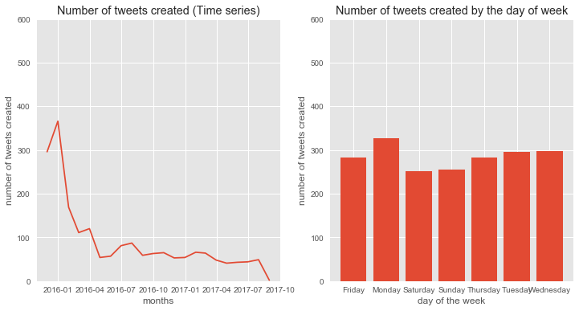

```python
#Transforming the data
df.set_index('timestamp', inplace=True)
df.index = df.index.astype('datetime64')

# Getting the number of new tweets by month
timeseries = df.resample('M').count()['tweet_id']
timeseries = timeseries.reset_index()


# Getting the number of tweets created by day of the week
df = df.reset_index()

df['weekday'] = df['timestamp'].dt.dayofweek

weekday = {0: 'Monday', 1: 'Tuesday', 2: 'Wednesday', 3: 'Thursday',
           4: 'Friday', 5: 'Saturday', 6: 'Sunday'}

df['weekday'] = df['weekday'].map(weekday)

weekday = df.groupby('weekday').agg(len)['tweet_id']

weekday = weekday.reset_index()

fig, ax = plt.subplots(ncols=2, nrows=1, figsize=(12, 6))

# Plotting
sns.lineplot(timeseries['timestamp'], timeseries['tweet_id'], ax=ax[0], )
ax[0].set_title('Number of tweets created (Time series)')
ax[0].set_xlabel('months')
ax[0].set_ylabel('number of tweets created')
ax[0].set(ylim=(0, 600))


ax[1].bar(weekday['weekday'], weekday['tweet_id'])
ax[1].set(ylim=(0, 600))
ax[1].set_ylabel('number of tweets created')
ax[1].set_xlabel('day of the week')
ax[1].set_title('Number of tweets created by the day of week')

plt.show()
```

### Dogtype - Distribution

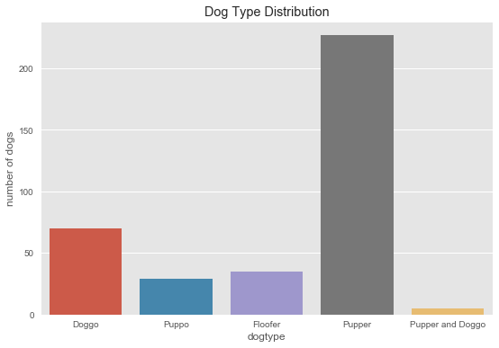

```python
# Creating the plot
fig, ax = plt.subplots(figsize=(9,6))
# Subsetting to not include the values that we couldn't discover the type of the dog
sns.countplot(df[df['dogtype'] != 'None']['dogtype'])
plt.title('Dog Type Distribution')
plt.xlabel('dogtype')
plt.ylabel('number of dogs')
plt.show()
```

As you can see, among the labeled dogs in our sample, is more common for the owner to post pictures of doggos and puppers. Puppos and Floofers, on the other hand, are less common.

### Most common breeds of dogs

Udacity's team had created a CNN model to classify the breeds of the dogs in each picture. This model has yield three guesses with the percentage of confiability of each of them.

As you will see, the first prediction always have higher probability of being right than the second and the third prediction according to the model. To exemplify this, I'll get the average confiability for each of the predictions below.

```python
prediction = []
# Here I created a for loop to get mean probability that the prediction is correct for all of the predictions
for i in ['p1_conf','p2_conf','p3_conf']:
    prediction.append(str(round(np.mean(df[i]),2)*100) + '%')

print('The average probability that the first prediction is correct is ' + prediction[0])
print('The average probability that the second prediction is correct is ' + prediction[1])
print('The average probability that the third prediction is correct is ' + prediction[2])
```

```
The average probability that the first prediction is correct is 59.0%
The average probability that the second prediction is correct is 13.0%
The average probability that the third prediction is correct is 6.0%
```

I'll use the first prediction to identify which breeds of dogs are more common in our dataset. I know that sometimes the predictions will not be correct, but, most of the time, they will.

I will use only the predictions that the model is confident that is a dog.

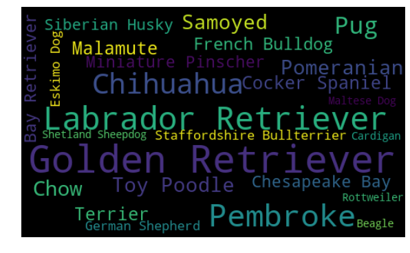

```python
# Subseeting to eliminate the null values
breeds = df[~df['p1'].isnull() & df['p1_dog']]['p1']
# Creating a single string with all dogs breeds, separated by an space
breeds = ' '.join(breeds)

# Creating the word cloud
fig, ax = plt.subplots(figsize=(10,10))
wordcloud = WordCloud(background_color='black', max_font_size=50,
                     max_words=25, width=500, height=300).generate(breeds)
plt.imshow(wordcloud, interpolation='bilinear')

# Removing the axis
plt.axis("off")

plt.show()
```

```python
print(df['p1'].value_counts()[0:10])
```

```
Golden Retriever      139
Labrador Retriever     95
Pembroke               88
Chihuahua              79
Pug                    54
Chow                   41
Samoyed                39
Pomeranian             38
Toy Poodle             38
Malamute               29
Name: p1, dtype: int64
```

I like word clouds to visualize data that has many categories. In this case, for example, there are more than 300 categories in this would make the plot very difficult to understand, but in the word cloud, is very clear what are the most common dogs.

### Popularity Metrics of a tweeter page

In Tweeter, there are two main metrics for measuring the engagement with a page.

- The likes (stored in the `favorite_count` variable).
- The retweets (stored in the `retweet_count` variable).

I believe that those variables have a high correlation, since the more a post is retweeted, the more likes it gain.

But, before investigate it, I wanna look at the distribution of both variables.

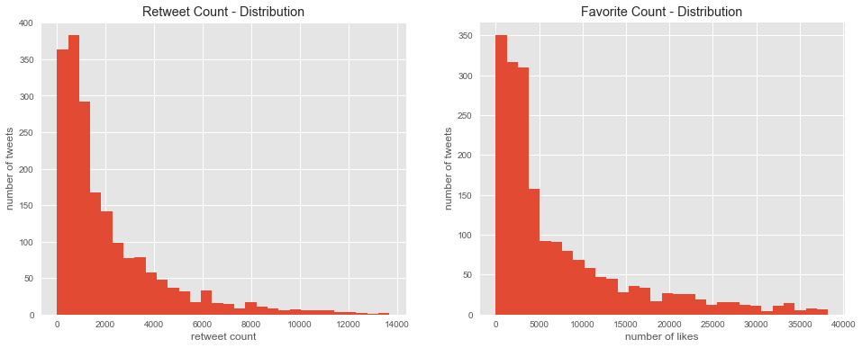

```python
fig, ax = plt.subplots(figsize=(16, 6), ncols=2, nrows=1, sharex=False,
                      sharey=False)

# Creating the two histograms
# I'll limit both of them to the 97.5 percentile to make the visualization better
ax[0].hist(df['retweet_count'], range=(0, np.nanpercentile(df['retweet_count'], 97.5)), bins=30)
ax[0].set_title('Retweet Count - Distribution')
ax[0].set_xlabel('retweet count')
ax[0].set_ylabel('number of tweets')


ax[1].hist(df['favorite_count'], range=(0, np.nanpercentile(df['favorite_count'], 97.5)), bins=30)
ax[1].set_title('Favorite Count - Distribution')
ax[1].set_xlabel('number of likes')
ax[1].set_ylabel('number of tweets')


plt.show()
```

The distributions of both variables are pretty similar in its shape, but they are on different scales. Both of them are right skewed, so the means (2645 and 8717) are higher than the medians (1275 and 3690).

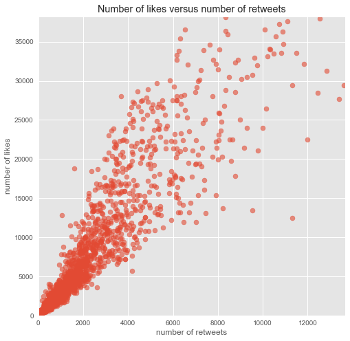

```
The correlation between the variables are: 0.93 and the p-value is: 0.0
```

```python
fig, ax = plt.subplots(figsize=(8,8))

# Creating the scatterplot
# Removing upper outliers using np.nanpercentile funtion
plt.scatter(df['retweet_count'], df['favorite_count'],
            alpha=0.6)
plt.xlim(0, np.nanpercentile(df['retweet_count'], 97.5))
plt.ylim(0, np.nanpercentile(df['favorite_count'], 97.5))
plt.xlabel('number of retweets')
plt.ylabel('number of likes')
plt.title('Number of likes versus number of retweets')



plt.show()

# Calculating the correlation between the two variables
correlation, p_value = pearsonr(df[~df['retweet_count'].isnull()]['retweet_count'].values,
                                df[~df['favorite_count'].isnull()]['favorite_count'].values)
correlation = round(correlation, 2)
print('The correlation between the variables are: ' +
      str(correlation) +
      ' and the p-value is: ' + str(p_value))
```

### Dogtypes versus popularity metrics

[figure not shown]

```python
# grouping by dogtype
dogtypes = df.groupby('dogtype').agg(['median'])[['retweet_count','favorite_count']]

# Creating a horizontal barplot using the pandas.plot function
dogtypes.plot(kind='barh', figsize=(9,8))
plt.legend(['Retweet count (mean)', 'Favorite count (mean)'])
plt.xlabel('mean')
plt.ylabel('dogtype')
plt.title('Mean number of retweets and favorite count by dogtype')
plt.show()
```

### Distribution of starting letters in the dog's names

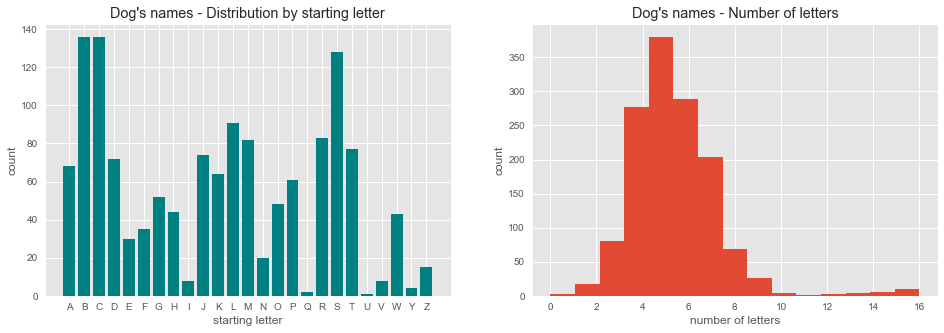

```python
# Creating the column
df['starting_letter'] = df['names'].str[0:1]

# Subsetting and grouping
letters = df[df['names'] != 'None'].groupby('starting_letter').agg(len)['tweet_id']
letters = letters.reset_index()


# Length dognames
length_dognames = []
for i in range(len(df)):
    if df['names'][i] != 'None':
        length_dognames.append(len(df['names'][i]))



# Creating the plot
fig, ax = plt.subplots(ncols=2, nrows=1, figsize=(16, 5))


ax[0].bar(x=letters['starting_letter'], height=letters['tweet_id'], color='#008080')
ax[0].set_title("Dog's names - Distribution by starting letter")
ax[0].set_xlabel("starting letter")
ax[0].set_ylabel('count')

ax[1].hist(length_dognames, range=(0, np.percentile(length_dognames, 99)), bins=15)
ax[1].set_title("Dog's names - Number of letters")
ax[1].set_xlabel("number of letters")
ax[1].set_ylabel('count')

plt.show()
```

This charts have shown that the majority of dogs have in the sample, usually, have names that have between 4 an 8 letters and starts with the letters a, b, c, d, l, m, r, s and t.

Also, it seems that is very uncommon to have a dog with a name that starts with the letters i, q, u and y.

### Was Brent correct all the time?

This page have created a community of fans and have developed it's own kind of language.

One episode that is famous among community members is the episode when one fan of the page has criticized the rating system of the plataform. As you can see below:

[figure not shown]

#### So, is possible to evaluate if the system used by the page to evaluate the dogs is correct or is it random?

One thing that I think that could be useful to help us answer this question, is to compare the rating system with the metrics of popularity of each tweet like the number of likes and retweets. If the rating system is not random, then the rating will have a high correlation with these metrics.

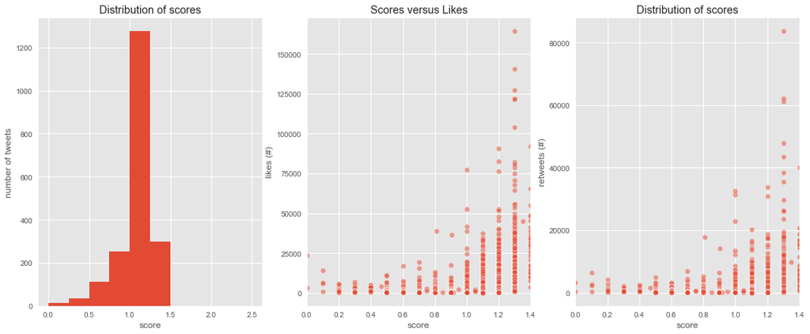

```
The correlation between the score and the variable favorite count is: 0.02

The p-value is: 0.3285876523803829

The correlation between the score and the variable retweet count is: 0.02

The p-value is: 0.3105720518259178
```

```python
fig, ax = plt.subplots(ncols=3, nrows=1, figsize=(18,7))

# Creating the histogram
ax[0].hist(df['score'], range=(0,2.5))
ax[0].set_title('Distribution of scores')
ax[0].set_xlabel('score')
ax[0].set_ylabel('number of tweets')

# Creating the scatterplot between score and favorite count
sns.scatterplot(df['score'], df['favorite_count'], alpha=0.5, ax=ax[1])
ax[1].set(xlim=(0, np.nanpercentile(df['score'], 99.5)))
ax[1].set_title('Scores versus Likes')
ax[1].set_xlabel('score')
ax[1].set_ylabel('likes (#)')

# Creating the scatterplot betweet
sns.scatterplot(df['score'], df['retweet_count'], alpha=0.5, ax=ax[2])
ax[2].set(xlim=(0, np.nanpercentile(df['score'], 99.5)))
ax[2].set_title('Distribution of scores')
ax[2].set_xlabel('score')
ax[2].set_ylabel('retweets (#)')

plt.show()

# Calculating the correlations
correlation, p_value = pearsonr(df['score'], df['favorite_count'])
correlation = round(correlation, 2)
print('The correlation between the score and the variable favorite count is: ' + str(correlation))
print('\nThe p-value is: ' + str(p_value))

correlation, p_value = pearsonr(df['score'], df['retweet_count'])
correlation = round(correlation, 2)
print('\nThe correlation between the score and the variable retweet count is: ' + str(correlation))
print('\nThe p-value is: ' + str(p_value))
```

The histogram shows that the majority of the scores are betweet 1 and 1.5.  
The correlation between the score and the two variables is almost 0.

So, it seems that the values attributed to each of the dogs doesn't follow the same pattern as the popularity metrics.

## Conclusions

#### Main takeaways

- The variables favorite_count and retweet_count have a high correlation
- The correlation between the score and the measures of popularity is almost 0
- The number of tweets created by month have been decreasing over time
- The most common breeds predicted by the CNN are the Golden retriever, Labrador Retriever, Pug, Chihuawa and Pembroke
- Within the dogs that have a dogtype explicitly, the most common are the doggo and the pupper.

#### Limitations

There are a lot of other things that could be explored, for example, the daily activity of the followers of the page, the number of likes and retweets by day or month. However, we don't have the data available to measure these variables.

#### Resources Used

- [Package Re](http://www.datasciencecourse.org/hw/hw1/recitation1.ipynb)
- [WordCloud](https://www.datacamp.com/community/tutorials/wordcloud-python)
- [Resample](https://pandas.pydata.org/pandas-docs/stable/generated/pandas.DataFrame.resample.html)
- [scipy.stats.pearsonr](https://docs.scipy.org/doc/scipy-0.14.0/reference/generated/scipy.stats.pearsonr.html)
- [Statuses Object](https://gist.github.com/dev-techmoe/ef676cdd03ac47ac503e856282077bf2)
- [Re.findall](https://stackoverflow.com/questions/7724993/python-using-regex-to-find-multiple-matches-and-print-them-out)
- [pd.read_json](https://pandas.pydata.org/pandas-docs/stable/generated/pandas.read_json.html)
- [join (strings)](https://www.geeksforgeeks.org/join-function-python/)
- [regex tutorial](https://regexone.com/)
- [tweepy documentation](http://docs.tweepy.org/en/v3.5.0/)